# Session 9: Neural Embeddings & Semantic Search

> *"Last week the model **learned** vectors from ratings. Today it learns them from **text** — so even a movie nobody has rated yet gets a vector."*

**Core idea:** the same "everything becomes a vector in one shared space" trick, now powered by neural nets — `word2vec → BERT → Sentence-Transformers` — then stored and searched at scale with a **vector database**.

## Matrix Factorization: Score as a Dot Product

- $R \approx P\,Q^{\mathsf T}$ — every user and movie becomes a length-$k$ vector.
- Rating = dot product: $\hat r_{ui} = p_u \cdot q_i$.
- Same length $k$ → **one shared space**.
- $k \le \min(\#\text{users}, \#\text{movies})$ — a **hard ceiling**: $\Sigma$ has at most that many singular values.

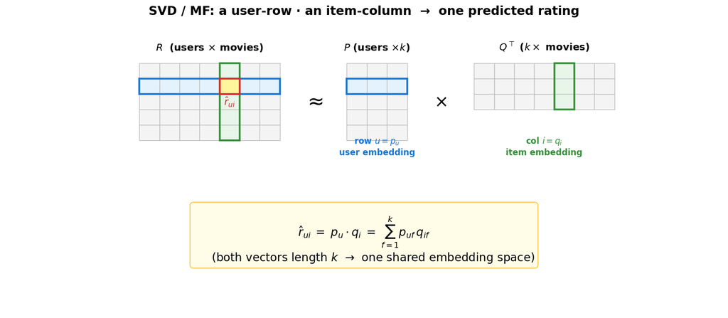

> **Details.** Row $u$ of $P$ is the user vector $p_u$; column $i$ of $Q^{\mathsf T}$ is the item vector $q_i$. Both have length $k$, so users and movies are points in the **same space**. $R$ is $m\times n$, so its rank is at most $\min(m,n)$: $\Sigma$ holds at most $\min(m,n)$ singular values and $k$ cannot exceed that.

## Similar Vectors, Similar Entries

- Cosine similarity (Session 7) now applies to **learned** vectors.
- Close **movie** vectors → similar movies.
- Close **user** vectors → similar taste.

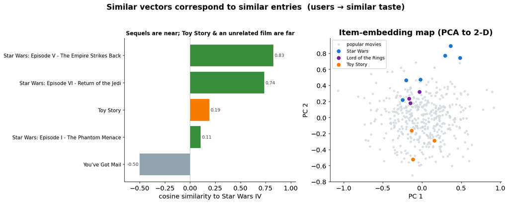

> *Star Wars IV*'s nearest neighbours are its own sequels; *Toy Story* and an unrelated film sit far away. Nearest-neighbour search over these vectors drives the rest of Session 9.

## A neural "layer" is just a matrix multiply (then a bend)

Before **AutoRec** (an autoencoder) one idea makes every neural net readable: a layer takes its input **vector**, **multiplies by a weight matrix**, adds a bias, then applies a non-linearity $\sigma$.

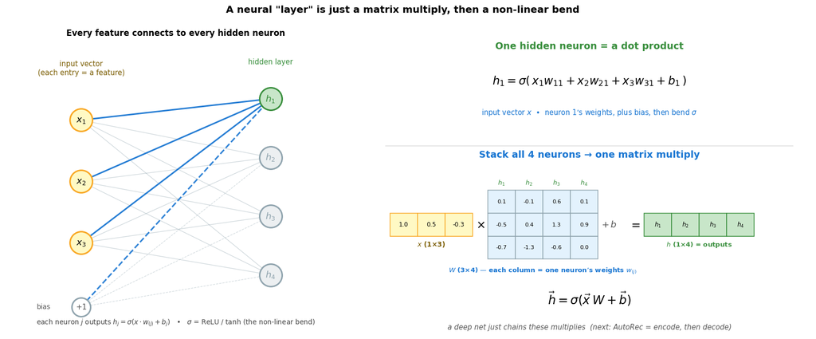

- The **input is a vector** — each entry is one **feature**, drawn as a neuron.
- Each **hidden neuron** is a **dot product** of the input with its own weights, plus a bias, then $\sigma$: $h_1=\sigma(x\cdot w_{(1)}+b_1)$.
- **Stack** every neuron's weights as columns of a matrix $W$ → the whole layer is one **matrix multiply**: $\vec h=\sigma(\vec x\,W+\vec b)$.
- A deep net just **chains** these multiplies.

## Autoencoder (AutoRec): Architecture

- Input = a movie's **rating column** (length = #users).
- **Encoder** down-projects → **bottleneck** ($k$ numbers).
- **Decoder** up-projects → reconstructed column.

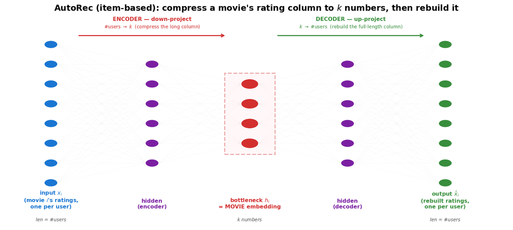

> The **encoder down-projects** the rating column from #users numbers down to just $k$ — the bottleneck (the movie embedding). The **decoder up-projects** those $k$ numbers back up to #users, rebuilding the column. (Item-based; AutoRec stores no movie vector — it computes one each time it runs the column through.)

## AutoRec: Computed vs. Learned Embeddings

- **Bottleneck $h_i$** = movie embedding — **computed** by the encoder.
- **Decoder row $V_u$** = user embedding — a **learned** weight.
- $\hat r_{ui} = h_i \cdot V_u$ — the same dot product as MF.

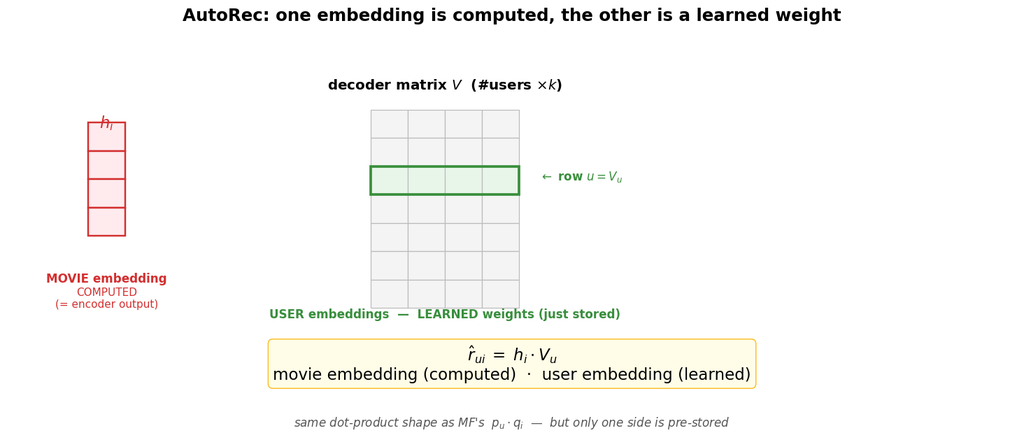

```
Symmetric note: a USER-based AutoRec flips it — feed a user's rating ROW (length = #movies),
 the bottleneck becomes the USER embedding, and the decoder rows become MOVIE embeddings.
```

## SVD vs. AutoRec: Calculated vs. Learned

- Same destination: every user and movie is a vector in one shared space; a rating is their dot product.
- The difference is **how each vector is produced**.

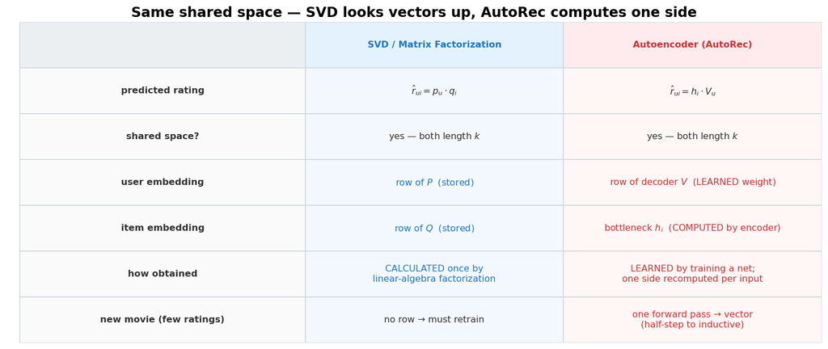

> SVD looks both vectors up (calculated once by factorization); AutoRec computes one side with the encoder and stores the other, so a new movie gets a vector in a single forward pass.

## word2vec (skip-gram): predict a word's neighbours

So far every embedding came from **ratings**. To embed things *nobody has rated yet*, we turn to **text** — starting with the simplest unit: the **word**.

- The **objective**: from the **center word**, predict each surrounding **context word**.
- Slide a window over plain text → that gives the (input → output) training pairs.
- The running text is its **own supervision** — no human labels.

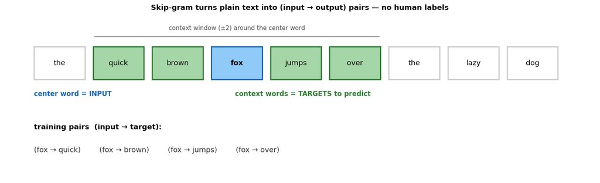

## Turn that objective into a network

- Feed the center word as a **one-hot** vector ($V = 10{,}000$); train a small **2-matrix net** to predict its context words.
- The matrix that builds the hidden layer **is** the embedding table — that is the part we keep.

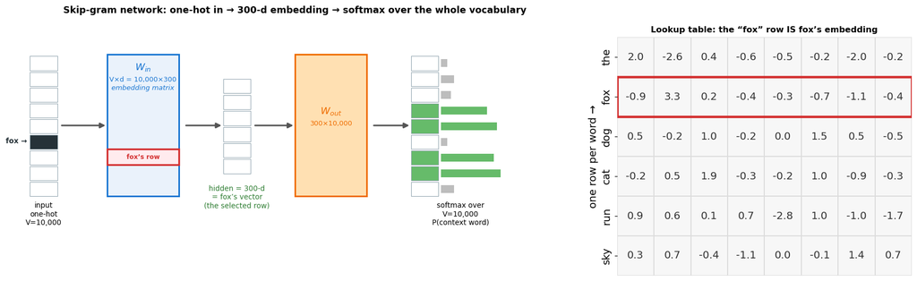

```
one-hot · W_in selects a row — so each of the V rows of W_in is one word’s d-dim embedding.
```

## Wait — this is *matrix factorization* again

Skip-gram's loss, unrolled, factorizes a giant **word × context co-occurrence matrix** into two thin matrices $W_{in}, W_{out}$ — *exactly* the $R \approx P\,Q^{T}$ move from Session 8 (Levy & Goldberg, 2014).

- Session 8: factor the **user × item** matrix → user/item vectors
- word2vec: factor the **word × context** matrix → word vectors

> 🧠 Same engine, different matrix. "Learn vectors by factorizing a co-occurrence table" is the one idea under collaborative filtering **and** word embeddings.

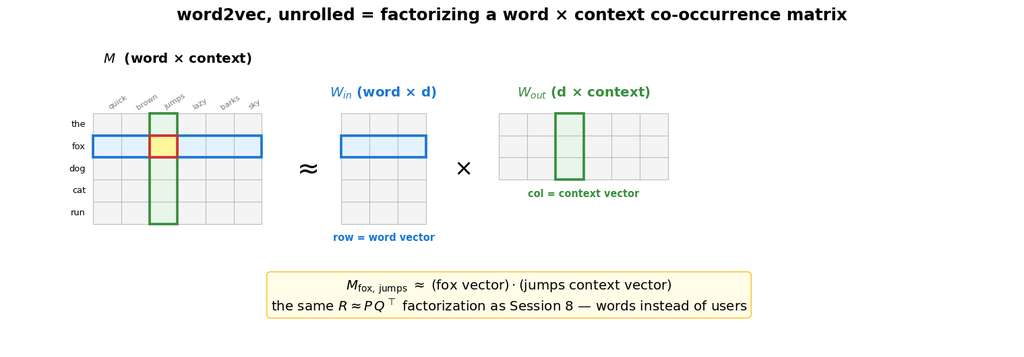

## The payoff: neighbours & word arithmetic

- No need to train it yourself — **pretrained vectors** are a download away (here **GloVe**, trained on 6 billion words).
- **Nearby vectors = related words.** And relations become **offsets** you can add and subtract: **king − man + woman ≈ queen**.

```
nearest to “king”   : ['prince', 'queen', 'ii', 'emperor', 'son']
nearest to “coffee” : ['drink', 'drinks', 'wine', 'tea', 'beer']
analogy  king − man + woman       ≈  queen
analogy  paris − france + italy   ≈  rome
analogy  walked − walk + swim     ≈  swam
```

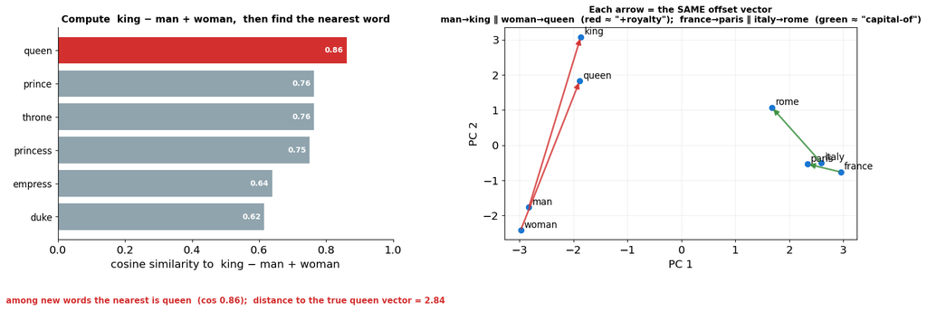

## The catch: one word → **one** vector

word2vec gives every word a *single* fixed vector. But meaning depends on **context**:

- *"sat on the river **bank**"* 🌊
- *"deposited cash at the **bank**"* 💰

word2vec blends both senses into one blurry point. Worse, it has **no vector for a sentence** — averaging word vectors throws away word order entirely (*"dog bites man" = "man bites dog"*).

**We need vectors that change with context.** Enter the Transformer.

## BERT: what it does and how it was trained

- BERT reads the **whole sentence at once** (not left-to-right) and gives **every token its own context-dependent vector**.
- **Training objective — masked language modeling:** hide ~15% of the tokens and predict each one from the **rest of the sentence**, using both left and right context. No human labels needed.
- *Plus a small **next-sentence-prediction** task: does sentence B follow sentence A?*
- The masked-word prediction is only the **training signal**; at the end we keep **one contextual vector per token** (a sentence vector = **pool** those token vectors, e.g. their mean).

*Diagrams in this section are schematic, for intuition — not the full architecture.*

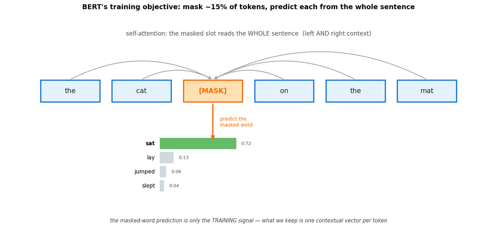

## BERT: pretraining vs. fine-tuning

[figure not shown]

Same encoder, reused: pretrain with masked-LM (+ next-sentence prediction), then transfer the weights and swap in a task head. Schematic, not the full architecture.

## How a sentence enters the model

[figure not shown]

Each token id looks up a row of the embedding matrix; the rows stack into the T×d input matrix (T tokens, each a d-dim vector) that enters the first transformer block.

## Each token becomes a query, a key and a value

[figure not shown]

One token vector × three learned matrices (W_Q, W_K, W_V) → its query, key and value.

## Attention is a soft dictionary lookup

[figure not shown]

The query is matched against every key to get weights; the new vector is the weighted sum of the values (line thickness = weight).

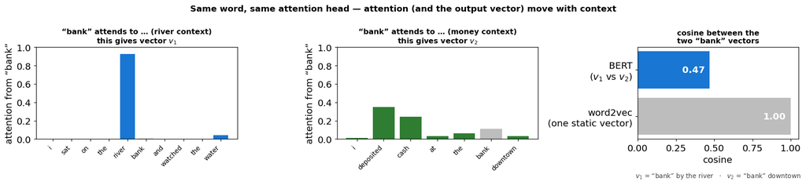

```
word2vec: both “bank”s identical (cos 1.00).  BERT: cos = 0.47 — context split them.
```

## But raw BERT is *bad* at sentence similarity

Tempting plan: to compare two sentences, average BERT's token vectors (or take the `[CLS]` token) and use cosine. **It works poorly** — vanilla BERT was never trained so that *cosine distance = meaning*. Unrelated sentences often score deceptively high.

**Sentence-Transformers (SBERT)** fix this with **contrastive fine-tuning**:

- feed **pairs** of sentences through the same BERT (a *siamese* setup)
- **pull** paraphrases together, **push** unrelated sentences apart

The loss is just **softmax cross-entropy** over the batch: among the anchor $\vec a$ and all candidate sentences $\vec s_j$, make the **true match $\vec p$ the most similar**.

$$\mathcal{L} \;=\; -\log \frac{e^{\cos(\vec a,\vec p)}}{\sum_j e^{\cos(\vec a,\vec s_j)}}$$

Softmax the cosines → a probability per candidate → push the probability of the **right pair toward 1**.

Now one forward pass → **one sentence vector**, and **cosine actually means similarity**.

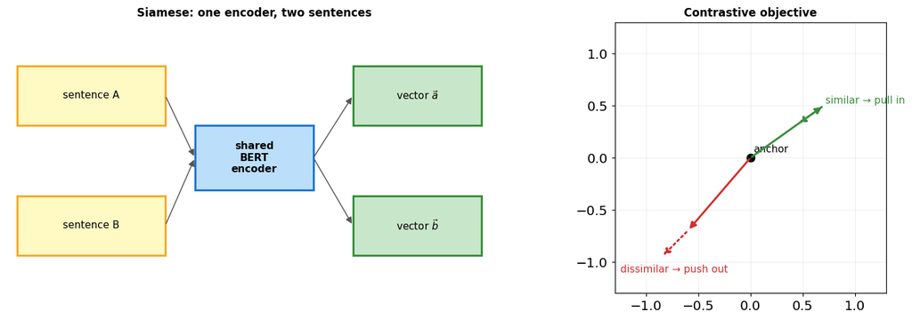

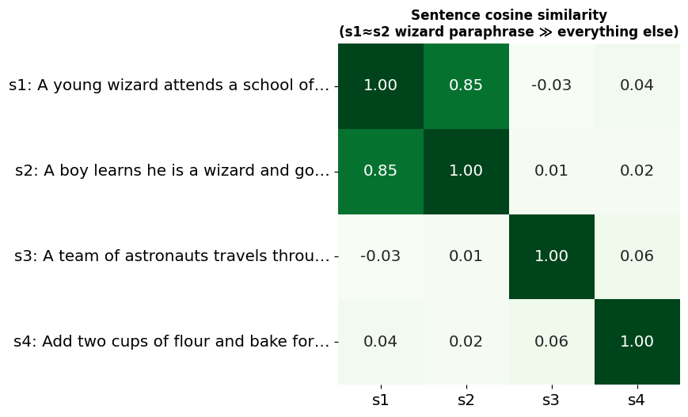

```
wizard paraphrase  s1·s2 = 0.85   vs   wizard·recipe  s1·s4 = 0.04
```

## Embedding our movies: text → vectors → a map

Now point SBERT at the **MovieLens** catalogue. Each movie's description becomes a 384-dim vector. Project to 2-D with **PCA** (Session 8) and colour by genre: unlike the *collaborative* embeddings (which clustered by viewing taste), **text** embeddings cluster by **theme/genre** — because that's what the words describe.

```python
# Loading a sentence-embedding model and embedding text is just two steps (the same .encode() API
# as the sentence demo above).
from sentence_transformers import SentenceTransformer

sbert = SentenceTransformer('all-MiniLM-L6-v2')         # download once, then cached locally

# mv.text = each popular movie's description; encode -> ONE 384-d vector per movie
EMB = sbert.encode(mv.text.tolist(), normalize_embeddings=True, show_progress_bar=False)
print(EMB.shape)                                         # (n_movies, 384) — a vector per movie
```

```
(450, 384)
```

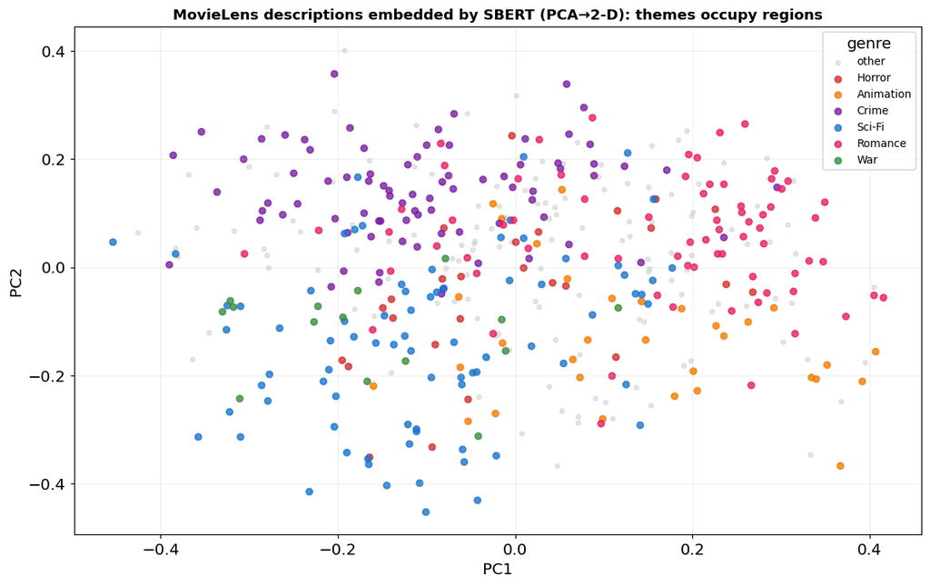

```
Because you liked  «Toy Story (1995)»:
   0.76   Toy Story 3 (2010)   [Adventure]
   0.74   Toy Story 2 (1999)   [Adventure]
   0.35   Back to the Future Part II (1989)   [Adventure]
   0.34   A.I. Artificial Intelligence (2001)   [Adventure]
   0.31   Jumanji (1995)   [Adventure]

Because you liked  «Matrix, The (1999)»:
   0.58   Matrix Reloaded, The (2003)   [Action]
   0.47   The Imitation Game (2014)   [Drama]
   0.46   Matrix Revolutions, The (2003)   [Action]
   0.41   2001: A Space Odyssey (1968)   [Adventure]
   0.39   Beautiful Mind, A (2001)   [Drama]
```

## Cold-start, solved: a brand-new movie nobody has rated

Collaborative filtering is stuck on a brand-new title — **no ratings → no vector**. But text embeddings are **inductive**: feed *any* description through SBERT and you get a vector *immediately*, placeable next to everything else. Take a **2024 release** — well after MovieLens-small ends (~2018), so it is genuinely unseen — embed its plot, and find its nearest catalogue neighbours:

```
New (unrated, 2024) movie:
  “On a harsh desert planet, a young hero rises to lead a rebellion against an evil galactic empire — a science-fiction space epic of starships, prophecy and interplanetary war.”

Nearest movies in the catalogue:
   0.47   Star Wars: Episode III - Revenge of the Sith (2005)   [Action]
   0.44   Star Wars: Episode V - The Empire Strikes Back (1980)   [Action]
   0.41   Star Trek (2009)   [Action]
   0.40   300 (2007)   [Action]
   0.40   Star Wars: Episode VI - Return of the Jedi (1983)   [Action]
```

## Storing & searching vectors at scale: a vector database

We have a few hundred vectors today, millions in production. A **vector database** stores embeddings and answers *"give me the nearest k to this query vector"* fast. **ChromaDB** does it in ~5 lines:

```
import chromadb
client = chromadb.Client()
col = client.create_collection("movies")
col.add(ids=..., embeddings=..., documents=..., metadatas=...)
col.query(query_embeddings=..., n_results=5)
```

Under the hood it doesn't compare your query to *every* vector — that's **brute force** and too slow. It builds an **approximate nearest-neighbour** index: **HNSW**.

[figure not shown]

The whole pipeline: movie plots and the user query share one embedding model; document vectors live in the database, the query vector is matched against them, top-k returned.

```
stored 450 movie vectors in ChromaDB (cosine / HNSW index)
```

## Why HNSW beats brute force

**Brute force:** compare the query to **all N** vectors → exact, but $O(N)$ per query. Hopeless at millions × many queries/sec.

**HNSW** (Hierarchical Navigable Small World) builds a **multi-layer proximity graph**:

- sparse top layers = "express lanes" for big jumps across the space
- dense bottom layer = fine local steps
- search = **greedy hop** toward the query, descending layers — only $O(\log N)$ nodes visited

You trade a tiny bit of recall for **orders-of-magnitude** speed. That's the engine inside Chroma, FAISS, pgvector, Pinecone, …

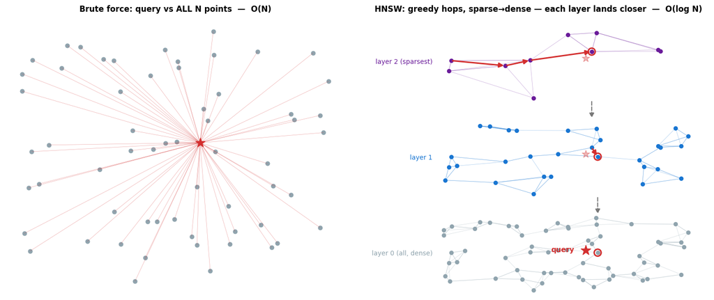

## Semantic search: type what you want, get movies

The payoff. Write a free-text wish — not a title, not a tag — embed it with the **same** SBERT model, and ask ChromaDB for the nearest movie vectors. Meaning matches, not keywords.

```
🔎  “a young hero learns magic at a wizard school”
   sim 0.48   Harry Potter and the Order of the Phoenix (2007)   [Adventure]
   sim 0.45   Harry Potter and the Sorcerer's Stone (a.k.a. Harry Potter and the Philosopher's Stone) (2001)   [Adventure]
   sim 0.43   Wizard of Oz, The (1939)   [Adventure]
   sim 0.41   Breakfast Club, The (1985)   [Comedy]
   sim 0.37   Rushmore (1998)   [Comedy]

🔎  “a hacker discovers reality is a simulation”
   sim 0.52   Matrix, The (1999)   [Action]
   sim 0.48   Tron (1982)   [Action]
   sim 0.38   Truman Show, The (1998)   [Comedy]
   sim 0.37   Inception (2010)   [Action]
   sim 0.37   Total Recall (1990)   [Action]

🔎  “a dark crime story about the mafia”
   sim 0.58   Donnie Brasco (1997)   [Crime]
   sim 0.54   Departed, The (2006)   [Crime]
   sim 0.52   Goodfellas (1990)   [Crime]
   sim 0.51   L.A. Confidential (1997)   [Crime]
   sim 0.47   Godfather, The (1972)   [Crime]
```

## Key Takeaways

1. **Text → vectors.** Neural embeddings give *any* item a vector from its words — no ratings needed.
2. **word2vec** = factorize a word-co-occurrence matrix (same trick as Session 8's $R\approx PQ^T$); the hidden layer *is* the embedding — a pure **down-projection**, no activation.
3. **Static → contextual:** word2vec gives one fixed vector per word; **BERT** reads the whole sentence — trained by **masking words and predicting them** — and outputs a vector per word *in context* via self-attention.
4. **Contextual → comparable:** **Sentence-Transformers** fine-tune **contrastively** (softmax cross-entropy: pull true pairs together) so **cosine = meaning**; **pool** the token vectors into one sentence vector.
5. **Cold-start solved:** embed a brand-new description (e.g. a 2024 movie) and it lands right next to similar items.
6. **Vector DB (ChromaDB)** stores embeddings; **HNSW** searches them in $O(\log N)$ instead of brute-force $O(N)$.

## Where this goes next

- **Retrieval-Augmented Generation (RAG):** this exact pipeline — embed → vector DB → nearest-k — is how LLMs fetch relevant context before answering.
- **Multimodal & two-tower (Session 10):** the same idea embeds images, audio, users & items into *one* space — e.g. **CLIP** puts a movie's **poster** and its text in one shared space, trained the same contrastive way.
- **Practice:** generate text embeddings, test semantic similarity, build a ChromaDB recommender, and run the **cold-start** test — invent a new movie, find its neighbours.